# quantified_self

Pranav

July 26, 2015

## Background

Using devices such as Jawbone Up, Nike FuelBand, and Fitbit it is now possible to collect a large amount of data about personal activity relatively inexpensively. These type of devices are part of the quantified self movement – a group of enthusiasts who take measurements about themselves regularly to improve their health, to find patterns in their behavior, or because they are tech geeks.

## Goal of the project

The goal of your project is to predict the manner in which the observation set did their exercise. This is the “classe” variable in the training set. The project contains a report describing how the model was built, how cross validation was used, what the out of sample error is, in addition to the design choices. As part of the project, the model is also expected to predict a test set of 20 observations

## Dataset used for this project is derived from

Velloso, E.; Bulling, A.; Gellersen, H.; Ugulino, W.; Fuks, H. Qualitative Activity Recognition of Weight Lifting Exercises. Proceedings of 4th International Conference in Cooperation with SIGCHI (Augmented Human ’13) . Stuttgart, Germany: ACM SIGCHI, 2013.

## Let’s load the requisite packages

```r
library(caret)
```

```r
library(ggplot2)
library(rpart.plot)
library(randomForest)
library(rpart)
```

## Let’s set a seed so that the results are reproducible

```r
set.seed(99999)
```

## Let’s load the training and testing data. First we download the file and then we load the data into our variables training_data and testing_data respectively

```r
download.file("https://d396qusza40orc.cloudfront.net/predmachlearn/pml-training.csv", method="curl",destfile = "training.csv")
training_data <- read.csv("training.csv",na.strings = c("NA","","<NA>"))

download.file("https://d396qusza40orc.cloudfront.net/predmachlearn/pml-testing.csv", method="curl",destfile = "testing.csv")
testing_data <- read.csv("testing.csv",na.strings = c("NA","","<NA>"))
```

## Let’s check the training dataset to see what we get from the observations

```r
str(training_data)
```

```
## 'data.frame':    19622 obs. of  160 variables:
##  $ X                       : int  1 2 3 4 5 6 7 8 9 10 ...
##  $ user_name               : Factor w/ 6 levels "adelmo","carlitos",..: 2 2 2 2 2 2 2 2 2 2 ...
##  $ raw_timestamp_part_1    : int  1323084231 1323084231 1323084231 1323084232 1323084232 1323084232 1323084232 1323084232 1323084232 1323084232 ...
##  $ raw_timestamp_part_2    : int  788290 808298 820366 120339 196328 304277 368296 440390 484323 484434 ...
##  $ cvtd_timestamp          : Factor w/ 20 levels "02/12/2011 13:32",..: 9 9 9 9 9 9 9 9 9 9 ...
##  $ new_window              : Factor w/ 2 levels "no","yes": 1 1 1 1 1 1 1 1 1 1 ...
##  $ num_window              : int  11 11 11 12 12 12 12 12 12 12 ...
##  $ roll_belt               : num  1.41 1.41 1.42 1.48 1.48 1.45 1.42 1.42 1.43 1.45 ...
##  $ pitch_belt              : num  8.07 8.07 8.07 8.05 8.07 8.06 8.09 8.13 8.16 8.17 ...
##  $ yaw_belt                : num  -94.4 -94.4 -94.4 -94.4 -94.4 -94.4 -94.4 -94.4 -94.4 -94.4 ...
##  $ total_accel_belt        : int  3 3 3 3 3 3 3 3 3 3 ...
##  $ kurtosis_roll_belt      : Factor w/ 396 levels "-0.016850","-0.021024",..: NA NA NA NA NA NA NA NA NA NA ...
##  $ kurtosis_picth_belt     : Factor w/ 316 levels "-0.021887","-0.060755",..: NA NA NA NA NA NA NA NA NA NA ...
##  $ kurtosis_yaw_belt       : Factor w/ 1 level "#DIV/0!": NA NA NA NA NA NA NA NA NA NA ...
```

[output cut: 86 more lines]

## Data Cleanup

```r
training_data <- training_data[,colSums(is.na(training_data))==0]
testing_data <- testing_data[,colSums(is.na(testing_data))==0]
```

Additionally there are variables that contribute nothing to the dataset. It seems like columns 1 through 7 are important when collecting readings for book-keeping but don’t contribute anything meaningful for the analysis we want (correct vs. incorrect way of doing the exercise)

```r
training_data <- training_data[,-c(1:7)]
testing_data <- testing_data[,-c(1:7)]
```

## Cross Validation

Let’s divide the training data-set into two parts so that we can do some testing on that data and can then use the final model we select for test data set

```r
inTrain <- createDataPartition(training_data$classe,p=0.7,list=F)
training_train <- training_data[inTrain,]
training_test <- training_data[-inTrain,]
```

## Selection of Algorithm

This is a classification problem as opposed to a regression problem. Therefore we will use the classification tree and random forest as two possible ML algorithms and see which matches our need the most.

## Using rpart / Classification Trees

Let’s see the dependent variable in a table to see the distribution

```r
table(training_train$classe)
```

```
##
##    A    B    C    D    E
## 3906 2658 2396 2252 2525
```

### Classification Tree

Let’s create the model

```r
modFit <- rpart(classe ~ .,data=training_train,method ="class")
```

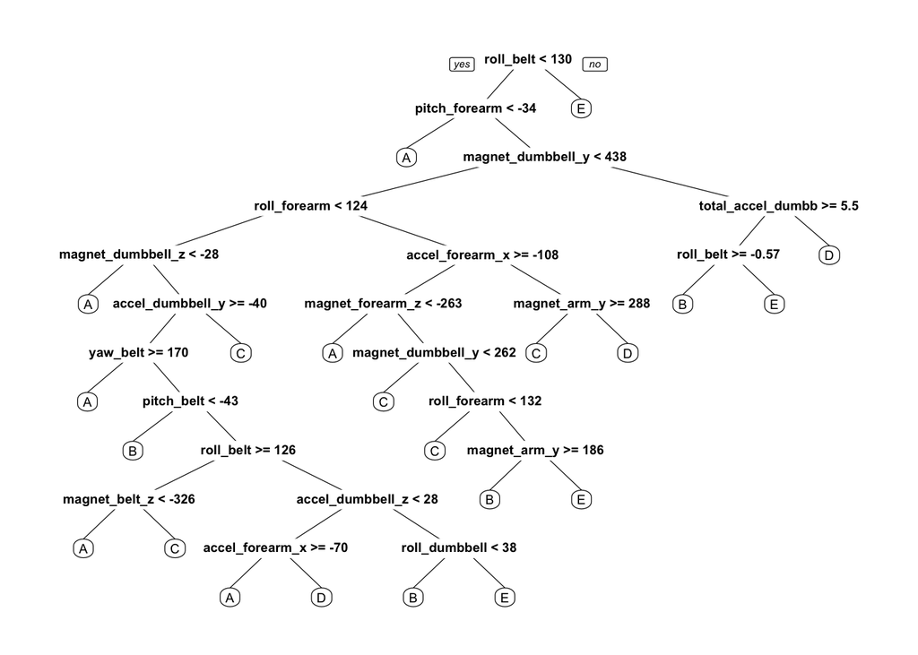

```r
rpart.plot(modFit)
```

Let’s test the model on the training subset we have alloted for testing

```r
predicted_values <- predict(modFit, newdata=training_test, type="class")
```

Let’s create the confusion matrix for these predicted values

```r
confusionMatrix(predicted_values,training_test$classe)
```

```
## Confusion Matrix and Statistics
##
##           Reference
## Prediction    A    B    C    D    E
##          A 1535  255   61  157   39
##          B   35  613   92   46   89
##          C   50  148  770   73   94
##          D   38   71   87  566   66
##          E   16   52   16  122  794
##
## Overall Statistics
##
##                Accuracy : 0.7269
##                  95% CI : (0.7154, 0.7383)
##     No Information Rate : 0.2845
##     P-Value [Acc > NIR] : < 2.2e-16
##
##                   Kappa : 0.6519
##  Mcnemar's Test P-Value : < 2.2e-16
##
## Statistics by Class:
##
##                      Class: A Class: B Class: C Class: D Class: E
## Sensitivity            0.9170   0.5382   0.7505  0.58714   0.7338
## Specificity            0.8784   0.9448   0.9249  0.94676   0.9571
## Pos Pred Value         0.7499   0.7006   0.6784  0.68357   0.7940
## Neg Pred Value         0.9638   0.8950   0.9461  0.92130   0.9410
## Prevalence             0.2845   0.1935   0.1743  0.16381   0.1839
## Detection Rate         0.2608   0.1042   0.1308  0.09618   0.1349
## Detection Prevalence   0.3478   0.1487   0.1929  0.14070   0.1699
## Balanced Accuracy      0.8977   0.7415   0.8377  0.76695   0.8455
```

## Conclusion:

We see that with the Classification Tree, we obtain accuracy of 72.69%. This is not a good enough accuracy for our needs as the error rate is well above 20% (27.31%)

## Using Random Forest

### Let’s see the dependent variable in a table to see the distribution

```r
table(training_train$classe)
```

```
##
##    A    B    C    D    E
## 3906 2658 2396 2252 2525
```

### Random Forest

Let’s create the model

```r
modFit2 <- randomForest(classe~.,data=training_train,method="class")
```

Let’s test the model on the training subset we have alloted for testing

```r
predicted_values_rf <- predict(modFit2, newdata=training_test, type="class")
```

Let’s create the confusion matrix for these predicted values

```r
confusionMatrix(predicted_values_rf,training_test$classe)
```

```
## Confusion Matrix and Statistics
##
##           Reference
## Prediction    A    B    C    D    E
##          A 1674    2    0    0    0
##          B    0 1134    7    0    0
##          C    0    3 1016   10    1
##          D    0    0    3  952    0
##          E    0    0    0    2 1081
##
## Overall Statistics
##
##                Accuracy : 0.9952
##                  95% CI : (0.9931, 0.9968)
##     No Information Rate : 0.2845
##     P-Value [Acc > NIR] : < 2.2e-16
##
##                   Kappa : 0.994
##  Mcnemar's Test P-Value : NA
##
## Statistics by Class:
##
##                      Class: A Class: B Class: C Class: D Class: E
## Sensitivity            1.0000   0.9956   0.9903   0.9876   0.9991
## Specificity            0.9995   0.9985   0.9971   0.9994   0.9996
## Pos Pred Value         0.9988   0.9939   0.9864   0.9969   0.9982
## Neg Pred Value         1.0000   0.9989   0.9979   0.9976   0.9998
## Prevalence             0.2845   0.1935   0.1743   0.1638   0.1839
## Detection Rate         0.2845   0.1927   0.1726   0.1618   0.1837
## Detection Prevalence   0.2848   0.1939   0.1750   0.1623   0.1840
## Balanced Accuracy      0.9998   0.9971   0.9937   0.9935   0.9993
```

## Running the test on testing_data

Let’s run our model to predict the testing data

```r
predicted_values_testing <- predict(modFit2, newdata=testing_data, type="class")
print(predicted_values_testing)
```

```
##  1  2  3  4  5  6  7  8  9 10 11 12 13 14 15 16 17 18 19 20
##  B  A  B  A  A  E  D  B  A  A  B  C  B  A  E  E  A  B  B  B
## Levels: A B C D E
```